# Code: Analysis of messaging and financing on demand for non-traditional cookstove adoption in Uganda

### 2.4.2 Randomization of wealth characteristic

No message vs Improve health

```r
Joint_Test4 = data_plus[ which(data_plus$No_message == 1 | data_plus$Improves_Health == 1),]

lm_JT4 = lm(Improves_Health ~ HH_PHONES+BICYCLE_DUMMY+CAR_DUMMY+MOTORCYCLE_DUMMY+RADIO_DUMMY+TIME_EMPLOYED+COWS_Dummy+TV_Dummy, data=Joint_Test4)
summary(lm_JT4)
```

```
##
## Call:
## lm(formula = Improves_Health ~ HH_PHONES + BICYCLE_DUMMY + CAR_DUMMY +
##     MOTORCYCLE_DUMMY + RADIO_DUMMY + TIME_EMPLOYED + COWS_Dummy +
##     TV_Dummy, data = Joint_Test4)
##
## Residuals:
##     Min      1Q  Median      3Q     Max
## -0.5777 -0.4936 -0.4001  0.5058  0.6333
##
## Coefficients:
##                   Estimate Std. Error t value Pr(>|t|)
## (Intercept)       0.544324   0.050543  10.769   <2e-16 ***
## HH_PHONES        -0.057063   0.022310  -2.558   0.0107 *
## BICYCLE_DUMMY     0.008181   0.031180   0.262   0.7931
## CAR_DUMMY        -0.013788   0.133431  -0.103   0.9177
## MOTORCYCLE_DUMMY -0.044633   0.049933  -0.894   0.3716
## RADIO_DUMMY      -0.018914   0.051999  -0.364   0.7161
## TIME_EMPLOYED     0.017728   0.030759   0.576   0.5645
## COWS_Dummy1       0.025224   0.033932   0.743   0.4574
## TV_Dummy1         0.021502   0.069591   0.309   0.7574
## ---
## Signif. codes:  0 '***' 0.001 '**' 0.01 '*' 0.05 '.' 0.1 ' ' 1
##
## Residual standard error: 0.5001 on 1116 degrees of freedom
## Multiple R-squared:  0.00753,    Adjusted R-squared:  0.0004154
## F-statistic: 1.058 on 8 and 1116 DF,  p-value: 0.3901
```

No message vs Time and money

```r
Joint_Test5 = data_plus[ which(data_plus$No_message == 1 | data_plus$Time_Money == 1),]

lm_JT5 = lm(Time_Money ~ BICYCLE_DUMMY+CAR_DUMMY+MOTORCYCLE_DUMMY+RADIO_DUMMY+TIME_EMPLOYED+COWS_Dummy+TV_Dummy, data=Joint_Test5)
summary(lm_JT5)
```

```
##
## Call:
## lm(formula = Time_Money ~ BICYCLE_DUMMY + CAR_DUMMY + MOTORCYCLE_DUMMY +
##     RADIO_DUMMY + TIME_EMPLOYED + COWS_Dummy + TV_Dummy, data = Joint_Test5)
##
## Residuals:
##     Min      1Q  Median      3Q     Max
## -0.6092 -0.5007 -0.2536  0.4950  0.7924
##
## Coefficients:
##                  Estimate Std. Error t value Pr(>|t|)
## (Intercept)       0.58020    0.04649  12.481   <2e-16 ***
## BICYCLE_DUMMY     0.02900    0.03122   0.929    0.353
## CAR_DUMMY        -0.11964    0.15346  -0.780    0.436
## MOTORCYCLE_DUMMY -0.07357    0.05126  -1.435    0.152
## RADIO_DUMMY      -0.07065    0.04908  -1.440    0.150
## TIME_EMPLOYED    -0.03787    0.03045  -1.244    0.214
## COWS_Dummy1      -0.03354    0.03436  -0.976    0.329
## TV_Dummy1        -0.13995    0.07771  -1.801    0.072 .
## ---
## Signif. codes:  0 '***' 0.001 '**' 0.01 '*' 0.05 '.' 0.1 ' ' 1
##
## Residual standard error: 0.4978 on 1108 degrees of freedom
## Multiple R-squared:  0.01528,    Adjusted R-squared:  0.009056
## F-statistic: 2.456 on 7 and 1108 DF,  p-value: 0.01679
```

```r
# +WOOD+TSF_PRIMARY+BUYWOOD_DUMMY+GATHERWOOD_DUMMY+MAXBID+MAXBIDNOVEL
```

No message vs Time and money and health

```r
Joint_Test6 = data_plus[ which(data_plus$No_message == 1 | data_plus$Time_Money_Health == 1),]

lm_JT6 = lm(Time_Money_Health ~ BICYCLE_DUMMY+CAR_DUMMY+MOTORCYCLE_DUMMY+RADIO_DUMMY+COWS_Dummy+TV_Dummy, data=Joint_Test6)
summary(lm_JT6)
```

```
##
## Call:
## lm(formula = Time_Money_Health ~ BICYCLE_DUMMY + CAR_DUMMY +
##     MOTORCYCLE_DUMMY + RADIO_DUMMY + COWS_Dummy + TV_Dummy, data = Joint_Test6)
##
## Residuals:
##     Min      1Q  Median      3Q     Max
## -0.6822 -0.4849 -0.4333  0.5151  0.5667
##
## Coefficients:
##                  Estimate Std. Error t value Pr(>|t|)
## (Intercept)       0.56678    0.04639  12.217   <2e-16 ***
## BICYCLE_DUMMY    -0.01528    0.03106  -0.492   0.6228
## CAR_DUMMY         0.18196    0.10694   1.702   0.0891 .
## MOTORCYCLE_DUMMY -0.02579    0.04748  -0.543   0.5872
## RADIO_DUMMY      -0.06657    0.04949  -1.345   0.1789
## COWS_Dummy1      -0.02582    0.03388  -0.762   0.4462
## TV_Dummy1         0.01811    0.06664   0.272   0.7858
## ---
## Signif. codes:  0 '***' 0.001 '**' 0.01 '*' 0.05 '.' 0.1 ' ' 1
##
## Residual standard error: 0.5 on 1120 degrees of freedom
## Multiple R-squared:  0.005952,   Adjusted R-squared:  0.0006264
## F-statistic: 1.118 on 6 and 1120 DF,  p-value: 0.3497
```

### 2.4.3 Randomization of cookstove related variables

No message vs Time money and health

```r
Joint_Test7 = data_plus[ which(data_plus$No_message == 1 | data_plus$Time_Money_Health == 1),]

lm_JT7 = lm(Time_Money_Health ~WOOD+TSF_PRIMARY+BUYWOOD_DUMMY+GATHERWOOD_DUMMY , data=Joint_Test7)
summary(lm_JT7)
```

```
##
## Call:
## lm(formula = Time_Money_Health ~ WOOD + TSF_PRIMARY + BUYWOOD_DUMMY +
##     GATHERWOOD_DUMMY, data = Joint_Test7)
##
## Residuals:
##     Min      1Q  Median      3Q     Max
## -0.6783 -0.4829 -0.3919  0.5171  0.6081
##
## Coefficients:
##                   Estimate Std. Error t value Pr(>|t|)
## (Intercept)       0.545562   0.091744   5.947 3.65e-09 ***
## WOOD             -0.144654   0.098235  -1.473   0.1412
## TSF_PRIMARY      -0.009047   0.033093  -0.273   0.7846
## BUYWOOD_DUMMY     0.050750   0.034739   1.461   0.1443
## GATHERWOOD_DUMMY  0.091031   0.051470   1.769   0.0772 .
## ---
## Signif. codes:  0 '***' 0.001 '**' 0.01 '*' 0.05 '.' 0.1 ' ' 1
##
## Residual standard error: 0.5 on 1122 degrees of freedom
## Multiple R-squared:  0.004327,   Adjusted R-squared:  0.0007773
## F-statistic: 1.219 on 4 and 1122 DF,  p-value: 0.3009
```

No message vs Time money

```r
Joint_Test8 = data_plus[ which(data_plus$No_message == 1 | data_plus$Time_Money == 1),]

lm_JT8 = lm(Time_Money~WOOD+TSF_PRIMARY+BUYWOOD_DUMMY+GATHERWOOD_DUMMY , data=Joint_Test8)
summary(lm_JT8)
```

```
##
## Call:
## lm(formula = Time_Money ~ WOOD + TSF_PRIMARY + BUYWOOD_DUMMY +
##     GATHERWOOD_DUMMY, data = Joint_Test8)
##
## Residuals:
##     Min      1Q  Median      3Q     Max
## -0.7762 -0.4964 -0.3765  0.5036  0.6914
##
## Coefficients:
##                  Estimate Std. Error t value Pr(>|t|)
## (Intercept)       0.52061    0.09041   5.758  1.1e-08 ***
## WOOD             -0.21198    0.08602  -2.464   0.0139 *
## TSF_PRIMARY       0.08625    0.03427   2.517   0.0120 *
## BUYWOOD_DUMMY     0.06784    0.03438   1.973   0.0487 *
## GATHERWOOD_DUMMY  0.10151    0.05093   1.993   0.0465 *
## ---
## Signif. codes:  0 '***' 0.001 '**' 0.01 '*' 0.05 '.' 0.1 ' ' 1
##
## Residual standard error: 0.4972 on 1111 degrees of freedom
## Multiple R-squared:  0.01497,    Adjusted R-squared:  0.01143
## F-statistic: 4.222 on 4 and 1111 DF,  p-value: 0.002138
```

No message vs Improves health

```r
Joint_Test9 = data_plus[ which(data_plus$No_message == 1 | data_plus$Improves_Health == 1),]

lm_JT9 = lm(Improves_Health ~WOOD+TSF_PRIMARY+BUYWOOD_DUMMY+GATHERWOOD_DUMMY , data=Joint_Test9)
summary(lm_JT9)
```

```
##
## Call:
## lm(formula = Improves_Health ~ WOOD + TSF_PRIMARY + BUYWOOD_DUMMY +
##     GATHERWOOD_DUMMY, data = Joint_Test9)
##
## Residuals:
##     Min      1Q  Median      3Q     Max
## -0.5869 -0.5144 -0.2422  0.4644  0.7578
##
## Coefficients:
##                  Estimate Std. Error t value Pr(>|t|)
## (Intercept)       0.24217    0.12205   1.984  0.04748 *
## WOOD              0.24985    0.12734   1.962  0.05001 .
## TSF_PRIMARY       0.09493    0.03442   2.758  0.00591 **
## BUYWOOD_DUMMY    -0.07252    0.03772  -1.922  0.05480 .
## GATHERWOOD_DUMMY -0.05134    0.05246  -0.979  0.32800
## ---
## Signif. codes:  0 '***' 0.001 '**' 0.01 '*' 0.05 '.' 0.1 ' ' 1
##
## Residual standard error: 0.4975 on 1120 degrees of freedom
## Multiple R-squared:  0.01439,    Adjusted R-squared:  0.01087
## F-statistic: 4.089 on 4 and 1120 DF,  p-value: 0.002697
```

## 2.5 Demand Curves

This is drawn by excel. See the excel file.

# 3. Correlations - Figure 2 and 3

## 3.1 Within Socio-Economic Variables

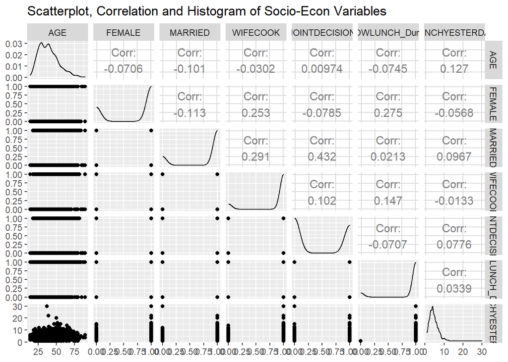

```r
library(GGally)
library(ggplot2)

### Plot the correlations

ggp1=ggpairs(data_plus,upper = list(continuous = wrap("cor", size = 4)), columns=c(which(colnames(data_plus)=="AGE"),which(colnames(data_plus)=="FEMALE"),which(colnames(data_plus)=="MARRIED"),which(colnames(data_plus)=="WIFECOOK"),which(colnames(data_plus)=="JOINTDECISION"),which(colnames(data_plus)=="KNOWLUNCH_Dummy"),which(colnames(data_plus)=="LUNCHYESTERDAY") ))
print(ggp1 + ggtitle("Scatterplot, Correlation and Histogram of Socio-Econ Variables"))
```

## 3.2 Within Wealth Variables

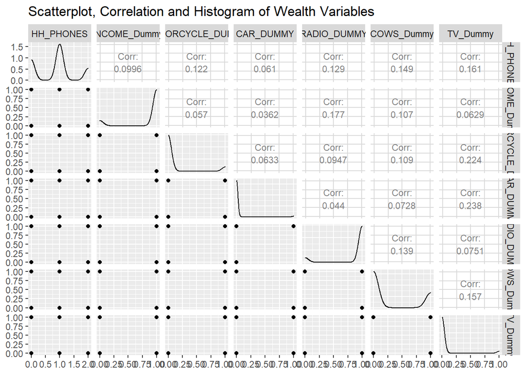

```r
### Clean the data format

data_plus$COWS_Dummy = as.numeric(data_plus$COWS_Dummy)
data_plus$TV_Dummy = as.numeric(data_plus$TV_Dummy)
data_plus$INCOME_Dummy = data_plus$INCOME
data_plus$INCOME_Dummy[data_plus$INCOME_Dummy == "No"] <- 0
data_plus$INCOME_Dummy[data_plus$INCOME_Dummy == "Yes"] <- 1
data_plus$INCOME_Dummy = as.numeric(data_plus$INCOME_Dummy)


### Plot Correlations
ggp2=ggpairs(data_plus,upper = list(continuous = wrap("cor", size = 3)), columns=c(which(colnames(data_plus)=="HH_PHONES"),which(colnames(data_plus)=="INCOME_Dummy"),which(colnames(data_plus)==" BICYCLE_DUMMY"),which(colnames(data_plus)=="MOTORCYCLE_DUMMY"),which(colnames(data_plus)=="CAR_DUMMY"),which(colnames(data_plus)=="RADIO_DUMMY"),which(colnames(data_plus)==" MAINEMPLOYER") ,which(colnames(data_plus)=="TIME_EMPLOYED "),which(colnames(data_plus)=="COWS_Dummy"),which(colnames(data_plus)=="TV_Dummy")))
print(ggp2 + ggtitle("Scatterplot, Correlation and Histogram of Wealth Variables"))
```

All the correlations within Wealth variables is so low that we do not need to worry about collinearity issues when put them in the regression model.

## 3.3 Within Cookstove use Variables

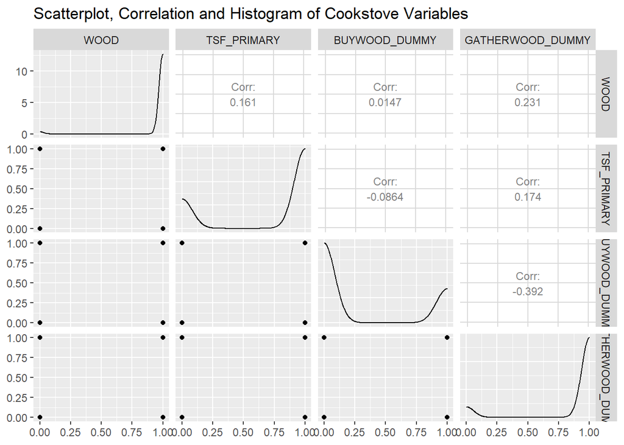

```r
ggp3=ggpairs(data_plus,upper = list(continuous = wrap("cor", size = 3)), columns=c(which(colnames(data_plus)=="WOOD"),which(colnames(data_plus)=="TSF_PRIMARY") ,which(colnames(data_plus)=="BUYWOOD_DUMMY"),which(colnames(data_plus)=="GATHERWOOD_DUMMY")))
print(ggp3 + ggtitle("Scatterplot, Correlation and Histogram of Cookstove Variables"))
```

## 3.4 Cross sectional Check - Gender Effect

We check the correlation between female and all cookstove variables

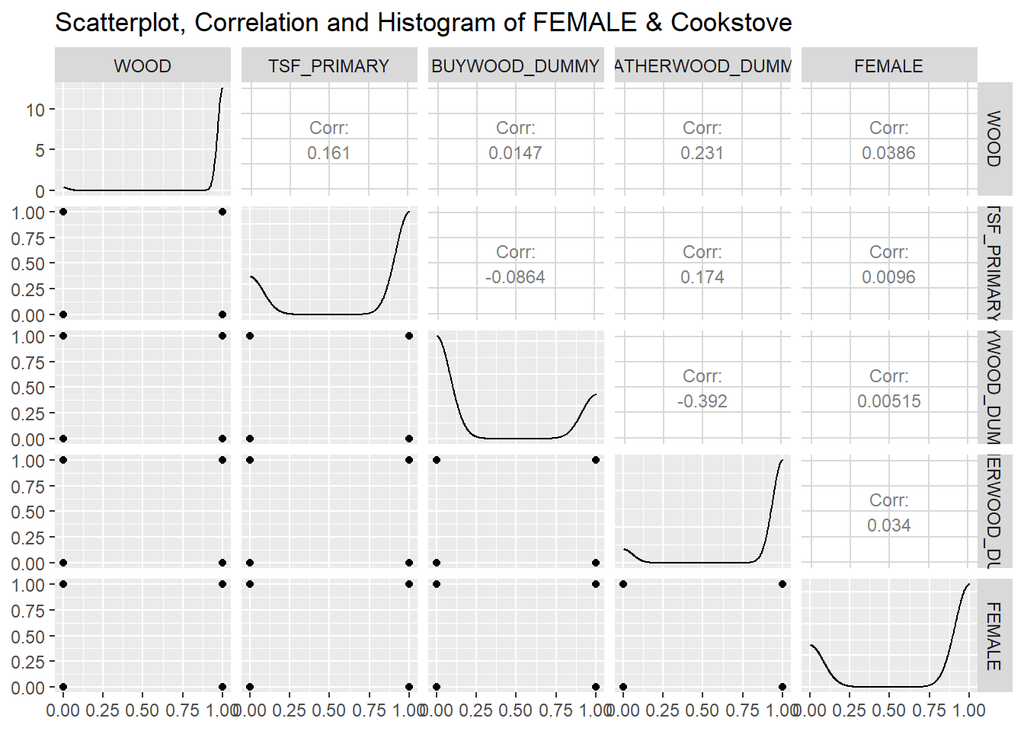

```r
ggp4=ggpairs(data_plus,upper = list(continuous = wrap("cor", size = 3)), columns=c(which(colnames(data_plus)=="WOOD"),which(colnames(data_plus)=="TSF_PRIMARY") ,which(colnames(data_plus)=="BUYWOOD_DUMMY"),which(colnames(data_plus)=="GATHERWOOD_DUMMY"),which(colnames(data_plus)=="FEMALE")))
print(ggp4 + ggtitle("Scatterplot, Correlation and Histogram of FEMALE & Cookstove"))
```

We can exclude the collinearty issue between gender and cookstove use.

# 4 Dependent on Explanatory Variables - Simple Linear Regressions - Figure 2 and 3

## 4.1 Correlation between Bidprices and the Explanatory Variables

### 4.1.1 Bidprices with Socio-econ Demographic Variables

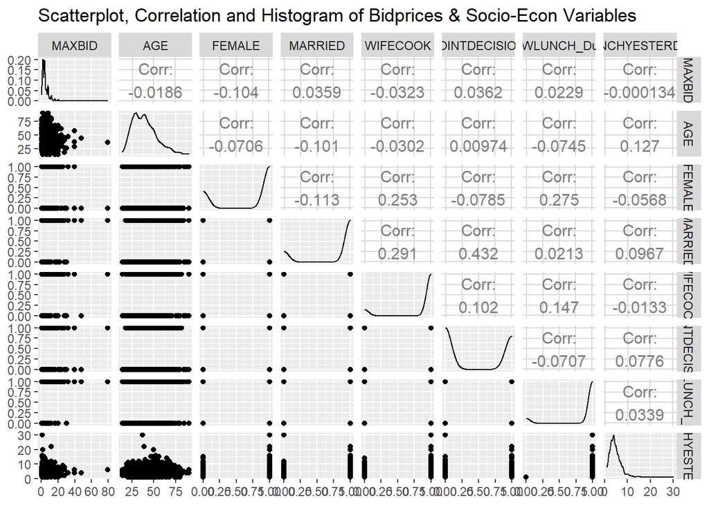

```r
### Bidprice with Socio-Econ Variables
ggp5=ggpairs(data_plus,upper = list(continuous = wrap("cor", size = 4)), columns=c(which(colnames(data_plus)=="MAXBID"),which(colnames(data_plus)=="AGE"),which(colnames(data_plus)=="FEMALE"),which(colnames(data_plus)=="MARRIED"),which(colnames(data_plus)=="WIFECOOK"),which(colnames(data_plus)=="JOINTDECISION"),which(colnames(data_plus)=="KNOWLUNCH_Dummy"),which(colnames(data_plus)=="LUNCHYESTERDAY") ))
print(ggp5 + ggtitle("Scatterplot, Correlation and Histogram of Bidprices & Socio-Econ Variables"))
```

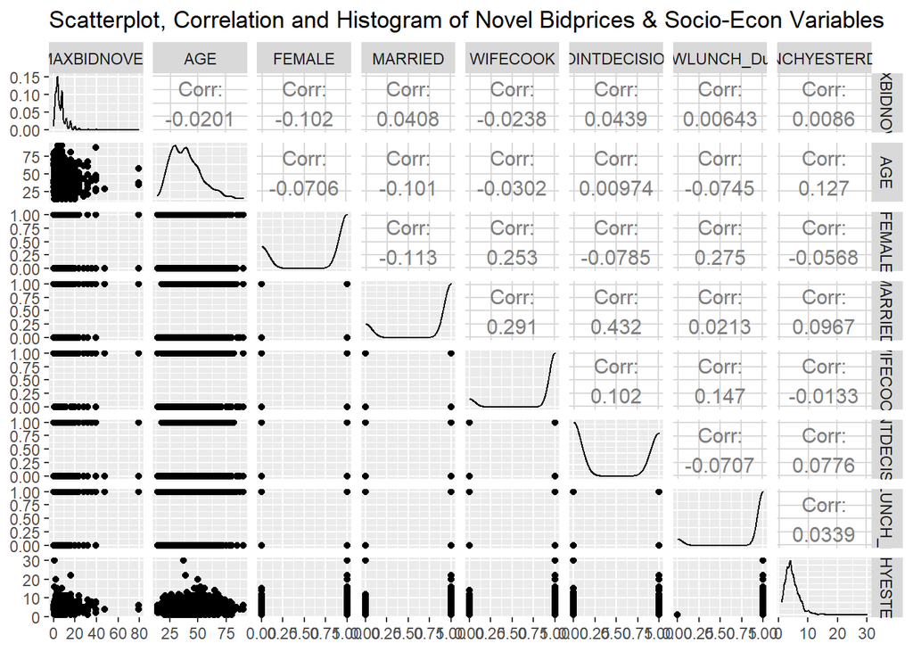

```r
### Novel bidprice with Socio-Econ Variables
ggp6=ggpairs(data_plus,upper = list(continuous = wrap("cor", size = 4)), columns=c(which(colnames(data_plus)=="MAXBIDNOVEL"),which(colnames(data_plus)=="AGE"),which(colnames(data_plus)=="FEMALE"),which(colnames(data_plus)=="MARRIED"),which(colnames(data_plus)=="WIFECOOK"),which(colnames(data_plus)=="JOINTDECISION"),which(colnames(data_plus)=="KNOWLUNCH_Dummy"),which(colnames(data_plus)=="LUNCHYESTERDAY") ))
print(ggp6 + ggtitle("Scatterplot, Correlation and Histogram of Novel Bidprices & Socio-Econ Variables"))
```

It shows that LUNCHYESTERDAY has ignorable correlation with either bidprices or novel bidprices. AGE, WIFEWOOK,MARRIED, JOINTDECISION and KNOWlUNCH_Dummy also have very week correlations with bidpices, respectively.